# In class notes

V. Markos

2026-11-24

# Loading Your Data

Having measured our reflexes, we now have to load those data into this script:

```r
# In this case, floats have been written using comma (,). Thus, we
# inform read.csv() that we want something else as a column separator
# (anything would work in this case, besides comma).
data <- read.csv('reflexes.csv', sep = ' ')
# head() returns the first six rows of the data frame
head(data)
```

```
##   X2.984
## 1  3,148
## 2  2,951
## 3  3,040
## 4  3,042
## 5  3,720
## 6  2,570
```

Now, to compute the mean value of times, we can just first make our times a vector:

```r
times <- data$X2.984
mean(times)
```

```
## [1] NA
```

This does not run saying that our data are not numeric?

To check the type of our loaded data, we can use this:

```r
str(data)
```

```
## 'data.frame':    29 obs. of  1 variable:
##  $ X2.984: chr  "3,148" "2,951" "3,040" "3,042" ...
```

Indeed, R has treated everything as characters! To resolve this:

```r
times <- as.numeric(data$X2.984)
mean(times)
```

```
## [1] NA
```

Now, everything is NA! This is due to us using commas instead of dots, so we have to first fix all this:

```r
times <- sub(',', '.', data$X2.984)
str(times)
```

```
##  chr [1:29] "3.148" "2.951" "3.040" "3.042" "3.720" "2.570" "2.796" "2.912" ...
```

Now, we can parse them as floats:

```r
times <- as.numeric(times)
mean(times)
```

```
## [1] 3.034931
```

But, is the mean value good enough? Let us plots a histogram to see the underlying distribution:

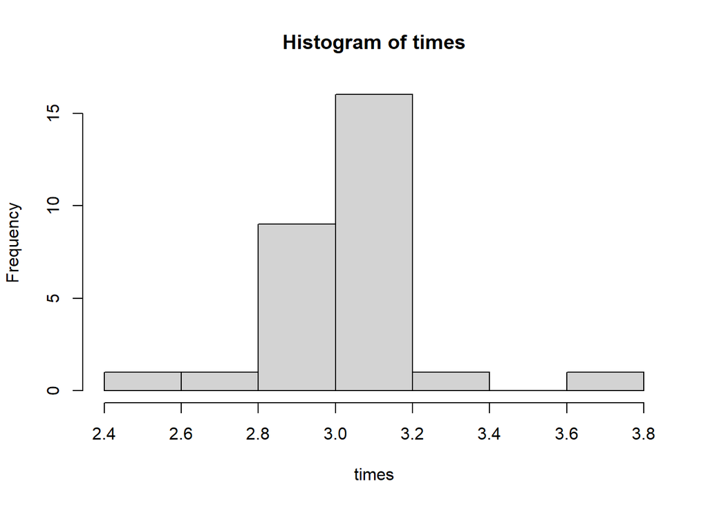

```r
hist(times)
```

Ideally, we should take into account extremes values that cancel, so we can measure distance from 3 instead of just reaction time:

```r
dist <- abs(times - 3)
mean(dist)
```

```
## [1] 0.1020345
```

Also, the corresponding histogram:

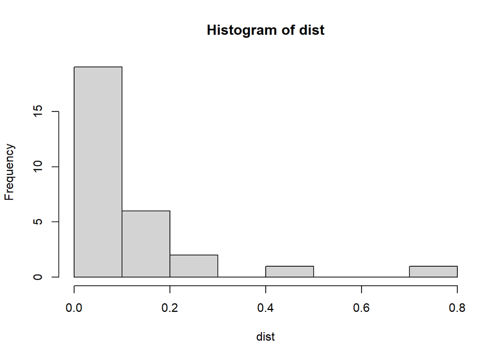

```r
hist(dist)
```

But, means might deceive you, especially in the presence of extreme values, so we also compute the median:

```r
median(dist)
```

```
## [1] 0.042
```

We might also consider the sample’s range:

```r
dist_range <- range(dist)
dist_range
```

```
## [1] 0.009 0.720
```

```r
dist_range_R <- dist_range[2] - dist_range[1]
print(dist_range_R)
```

```
## [1] 0.711
```

Also, to compute our standard deviation:

```r
var(dist)
```

```
## [1] 0.02271896
```

```r
sd(dist)
```

```
## [1] 0.1507281
```